# Laboratorio de Filogeografía: Género *Hamadryas*

## 2.5 Alineamiento

```
flowchart TD
    A[Cargar FASTA<br>desalineado] --> B[Alinear secuencias<br>utilizando MUSCLE]
    B --> C[Inspeccionar<br>alineamiento]
    C --> D[Cortar secuencias con<br>>50% datos faltantes]
    D --> E[Identificar<br>haplotipos]
```

Flujo de trabajo para alineamiento

```r
coi <- Biostrings::readDNAStringSet("hetaerina_lab/00_raw_data/raw_H_americana_COI.fasta")

# Ejecutar MUSCLE a través del paquete msa
coiAlign <- msa::msa(
  inputSeqs = coi,
  method    = "Muscle",  # Alternativas: "ClustalW", "ClustalOmega"
  verbose   = FALSE,
  type = "dna"
)
```

### 2.5.1 Inspección visual del alineamiento

```r
coiAlign_dnaBin <- msa::msaConvert(coiAlign, type = "ape::DNAbin")

rownames(coiAlign_dnaBin) <- str_extract(
  rownames(coiAlign_dnaBin),
  "Ham\\w{1,}\\d{1,}"
)
```

```r
pdf("hetaerina_lab/03_outputs/alignment_check.pdf", width = 10, height = 7, )
  ape::checkAlignment(coiAlign_dnaBin, what = 1)
  ape::checkAlignment(coiAlign_dnaBin, what = 2)
  ape::checkAlignment(coiAlign_dnaBin, what = 3)
  ape::checkAlignment(coiAlign_dnaBin, what = 4)
dev.off()
```

Recortar partes de las secuencias que tienen muchos datos faltantes

```
Number of sequences: 15
Number of sites: 629

No gap in alignment.

Number of segregating sites (including gaps): 25
Number of sites with at least one substitution: 25
Number of sites with 1, 2, 3 or 4 observed bases:
  1   2   3   4
604  25   0   0
```

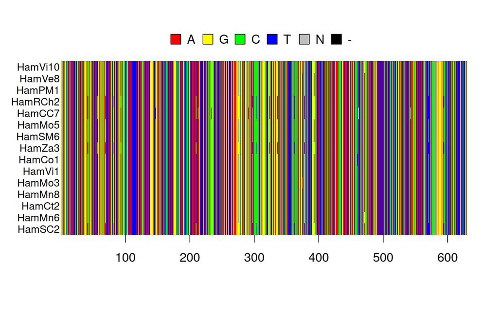

Ejemplo de alineamiento de 15 secuencias aleatorias. Podemos observar que cortamos las partes con gaps al principio y al final de la mayoría de las secuencias para quedarnos solo con los sitios que tienen suficientes datos.

```r
# Porcentaje de gaps por posición

aln_matrix <- as.character(coiAlign_dnaBin)

gaps_por_col <- apply(aln_matrix, 2, function(col) {
  mean(col == "-" | col == "n") * 100
})

cols_conservar <- which(gaps_por_col < 50)

coiAlign_trim <- coiAlign_dnaBin[, cols_conservar]

ape::write.dna(
  coiAlign_trim,
  file = "hetaerina_lab/02_alignment/alignment_coi_trimmed.fasta",
  format = "fasta"
)

par(cex = 1.2)
ape::checkAlignment(coiAlign_trim[runif(15,1,202),], what = 1)
```

## 2.6 Identificación de haplotipos

Recuperamos los haplotipos del alineamiento

```r
coiAlign_trim <- ape::read.dna("hetaerina_lab/02_alignment/alignment_coi_trimmed.fasta", format = "fasta")

coiHaplo <- pegas::haplotype(coiAlign_trim)
coiHaplo
```

```
Haplotypes extracted from: coiAlign_trim

    Number of haplotypes: 62
         Sequence length: 629

Haplotype labels and frequencies:

      I      II     III      IV       V      VI     VII    VIII      IX       X
      1       1       1       1       1       1       1       1       2       3
     XI     XII    XIII     XIV      XV     XVI    XVII   XVIII     XIX      XX
      1       1       5       1       1       1       2       1       3       2
    XXI    XXII   XXIII    XXIV     XXV    XXVI   XXVII  XXVIII    XXIX     XXX
      1       1      80       1       1       3       1       3       1       1
   XXXI   XXXII  XXXIII   XXXIV    XXXV   XXXVI  XXXVII XXXVIII   XXXIX      XL
      1       1       1       1       2       2       1       1       1       1
...
(use summary() to print all)
```

# 3 Análisis

## 3.1 Diversidad haplotípica y nucleotídica

Para caracterizar la variación genética del conjunto de secuencias analizamos tres estadísticas comúnmente utilizadas en estudios de genética de poblaciones y filogeografía: la diversidad haplotípica (Hd), la diversidad nucleotídica (π) y la D de Tajima.

**Diversidad haplotípica (Hd)**

Mide la probabilidad de que dos secuencias elegidas al azar en la muestra correspondan a haplotipos distintos. Este estadístico refleja tanto el número de haplotipos presentes como la distribución de sus frecuencias en la muestra. Valores altos de Hd (cercanos a 1) indican la presencia de múltiples haplotipos o una distribución relativamente equitativa de sus frecuencias.

El término $\frac{n}{n-1}$ es una corrección que se hace para cuando tenemos muestras pequeñas. Entre más grande sea N más se aproxima a 1.

**Diversidad nucleotídica (π)**

Representa el número promedio de diferencias nucleotídicas por sitio entre pares de secuencias de la muestra. Esta métrica proporciona una medida de qué tan distintas son las secuencias en una población.

$$\pi = \sum_{ij} x_i x_j \delta_{ij}$$

$x_i$ y $x_j$: Son las frecuencias de las secuencias (o haplotipos) $i$ y $j$.

$\delta_{ij}$: Es la proporción de diferencias nucleotídicas entre la secuencia $i$ y la secuencia $j$. Se calcula dividiendo el número de sitios diferentes entre la longitud total de la secuencia ($L$).

**D de Tajima**

Finalmente, calculamos la D de Tajima, una prueba estadística que compara dos estimadores de la diversidad genética ($\pi$ y $\theta$). Ya explicamos $\pi$, ahora vamos a describir $\theta$

$$\theta_w = \frac{S}{a_n}$$

$S$ es el número de sitios segregantes

$a_n = \sum_{i=1}^{n-1} \frac{1}{i} = \left( 1 + \frac{1}{2} + \frac{1}{3} + \dots + \frac{1}{n-1} \right)$ es el ajuste estadístico para poder comparar muestras con distinto número de individuos.

La comparación de $\pi$ con $\theta$ permite evaluar desviaciones del modelo neutral de evolución que pueden deberse a procesos demográficos (como expansiones poblacionales o cuellos de botella) o a la acción de la selección natural.

$$D = \frac{\pi - \theta_w}{\sqrt{Var(\pi - \theta_w)}}$$

$D$ Negativa ($D < 0$)

Ocurre cuando $\pi < \theta_w$, es decir hay muchos sitios polimórficos pero las diferencias entre los individuos son pequeñas. Se interpreta como que hay muchos alelos de baja frecuencia. Puede ocurrir cuando hay selección purificadora o selección positiva o, cuando hay una expansión demográfica reciente (la población crece rápido y hay muchas mutaciones nuevas poco comunes).

$D$ positiva ($D > 0$)

Ocurre cuando $\pi > \theta_w$, es decir hay pocos sitios polimórficos pero están repartidos entre los individuos. Se puede deber a que haya selección balanceadora (se mantiene más de una variante en la población) o cuando hay un cuello de botella (la población se reduce y solo quedan los alelos que ya eran frecuentes).

[Más información](https://ocw.mit.edu/courses/hst-508-quantitative-genomics-fall-2005/0900020a633e85338e9510495c2e01a6_tajimad1.pdf)

```r
Hd <- pegas::hap.div(coiHaplo, variance=TRUE)
Pi <- pegas::nuc.div(coiHaplo, variance = TRUE)
Dtajima <- pegas::tajima.test(coiHaplo)

Hd
```

```
[1] 0.8134082065 0.0006113713
```

```r
format(Pi, scientific = FALSE)
```

```
[1] "0.01458455648" "0.00005554843"
```

```r
Dtajima
```

```
$D
[1] -0.1760188

$Pval.normal
[1] 0.8602792

$Pval.beta
[1] 0.9013826
```

**Nota¿?**

1. ¿Qué nos dicen estas estimaciones acerca de la diversidad genética de H. americana?
2. ¿Cómo se interpreta la D de tajima en este caso?

## 3.2 Diferenciación genética

```
flowchart TD
    A[Convertir alineamiento<br>a objeto genind] --> B[Asignar estratos a probar]
    B --> C[Ejecutar Análisis de<br>Varianza Molecular]
```

Flujo de trabajo para estimar estructura genética (AMOVA)

```r
coi_genind <- adegenet::DNAbin2genind(coiAlign_trim)


metadata_COI <- read.csv("hetaerina_lab/01_metadata/metadata_COI.csv")
metadata_COI$locCode <- as.factor(metadata_COI$locCode)

adegenet::strata(coi_genind) <- metadata_COI
adegenet::setPop(coi_genind) <- ~locCode

coi_genind
```

```
/// GENIND OBJECT /////////

 // 202 individuals; 30 loci; 66 alleles; size: 168.1 Kb

 // Basic content
   @tab:  202 x 66 matrix of allele counts
   @loc.n.all: number of alleles per locus (range: 2-4)
   @loc.fac: locus factor for the 66 columns of @tab
   @all.names: list of allele names for each locus
   @ploidy: ploidy of each individual  (range: 1-1)
   @type:  codom
   @call: adegenet::DNAbin2genind(x = coiAlign_trim)

 // Optional content
   @pop: population of each individual (group size range: 1-10)
   @strata: a data frame with 13 columns ( accession, title, taxid, slen, organism, locCode, ... )
```

### 3.2.1 Análisis de varianza molecular AMOVA

El AMOVa es un análisis inspirado en el ANOVA. Cuantifica cómo se distribuyen las diferencias genéticas (variación) dentro y entre poblaciones o grupos. En poblaciones en las que no hay estructura genética (todos se reproducen con todos), esperamos que la mayor parte de la variación se encuentre dentro de los grupos, en cambio si encontramos que hay mayor variación entre grupos esperamos que exista estructura genética.

```r
amova_pop <- poppr::poppr.amova(coi_genind,
                                hier = ~locCode,
                                within=FALSE, # cuando T calcula la varianza dentro de los individuos
                                method = "ade4")

amova_pop
```

```
$call
ade4::amova(samples = xtab, distances = xdist, structures = xstruct)

$results
                 Df    Sum Sq    Mean Sq
Between samples  30 1597.3344 53.2444793
Within samples  171  157.3389  0.9201105
Total           201 1754.6733  8.7297177

$componentsofcovariance
                                Sigma         %
Variations  Between samples 8.1258181  89.82846
Variations  Within samples  0.9201105  10.17154
Total variations            9.0459286 100.00000

$statphi
                        Phi
Phi-samples-total 0.8982846
```

**Nota¿?**

1. ¿Qué podemos inferir acerca de la estructura genética de H. americana?
2. ¿En qué nivel biológico se encuentra la mayor parte de la variación?

### 3.2.2 Redes de haplotipos

Las redes de haplotipos nos ayudan a establecer hipótesis sobre las relaciones evolutivas que existen entre los haplotipos. La diferencia entre las redes y los árboles es que, estas, no están obligadas a bifurcarse siempre, puede haber “reticulaciones” (ciclos cerrados entre grupos de haplotipos).

La red se construye a partir de estimar las distancias entre haplotipos y conectarlos utilizando el principio de parsimonia. En particular se utiliza el método TCS (Templeton, Crandall and Sing, 1992).

[Más información sobre métodos de estimar redes de haplotipos](https://besjournals.onlinelibrary.wiley.com/doi/10.1111/2041-210X.12969)

```
flowchart TD
    A[Generar red de haplotipos<br>con haploNet a partir de<br>objeto haplotipos] --> B[Estimar frecuencia de<br>cada haplotipo]
    B --> C[Estimar frecuencia por<br>localidad]
    C --> D[Identificar haplotipo<br>por individuo]
    D --> E[Graficar la red]
    E --> F[Acomodar haplotipos]
```

Flujo de trabajo para estimar estructura genética (red de haplotipos)

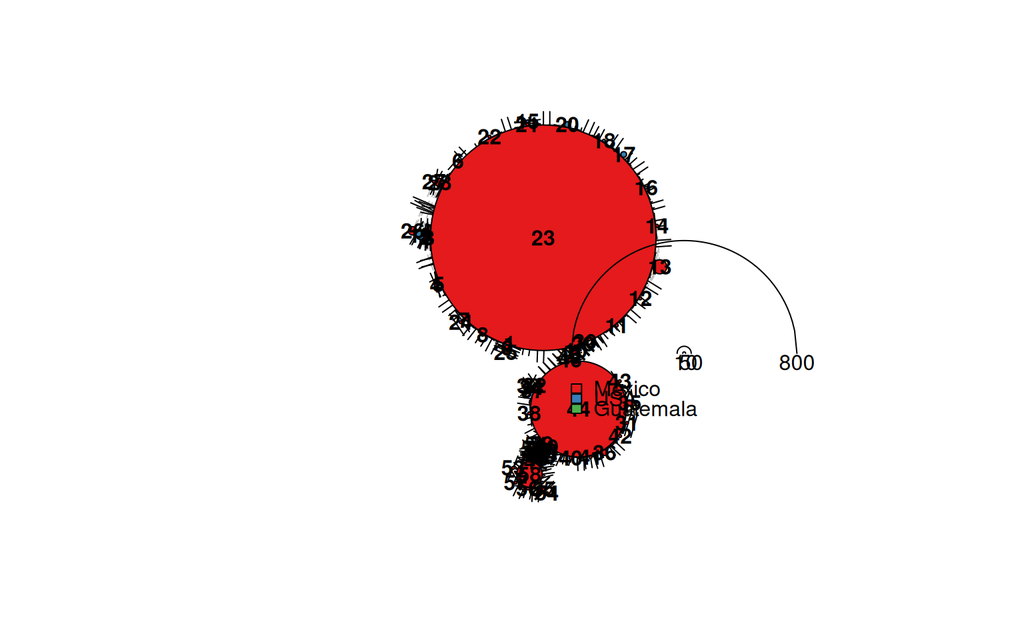

```r
rownames(coiHaplo) <- as.numeric(as.roman(rownames(coiHaplo)))
red <- pegas::haploNet(coiHaplo)


freq_hap <- summary(coiHaplo)
names(freq_hap) <- as.numeric(as.roman(names(freq_hap)))

# ¿Qué haplotipo tiene cada individuo?
tmp <- stack(setNames(attr(coiHaplo, "index"), rownames(coiHaplo))) # recuperar qué secuencia pertenece a qué haplotipo

ind_hap <- tmp %>%
  mutate(ind = as.integer(ind)) %>%
  group_by(values) %>%
  summarise(ind = list(ind), .groups = "drop") %>%
  tibble::deframe() |> unlist() # Agrupar los haplotipos usando como índice los indiviuos, es decir, generar un objeto en el que podamos saber qué haplotipo tiene cada individuo.

# Asignar colores a cada pais
countries <- metadata_COI$Country # Vamos a colorear los haplotipos por pais

countries <- factor(countries, levels = unique(countries))

n_countries <- length(unique(countries)) # Numero de localidades
paleta <- RColorBrewer::brewer.pal(min(n_countries, 8), "Set1") # Asignar un color a cada pais


# Matriz de proporción por haplotipo
prop_matriz <- ind_hap |>
  lapply(function(idx) table(countries[idx]) / length(idx)) |>
  bind_rows() |>
  as.matrix()

# Graficar
plot(
  red,
  size = freq_hap * 10, # tamaño de los haplotipos proporcional a su frecuencia
  pie = prop_matriz, # Asignar los colores por pais (usando graficas de pie)
  bg = paleta,
  legend = c(100, -10),
  show.mutation = 1, # mostrar número de mutaciones en las ramas
  main = "Red de haplotipos COI – Libélula"
)
```

Para modificar las coordenadas, en una terminal vamos a correr el script `mini_code_redhap.R`, después vamos a modificar las coordenadas y guardarlas en un nuevo objeto.

```r
# Primero abrir la terminal, abrir R y correr:
source("mini_code_redhap.R")  # carga la red
```

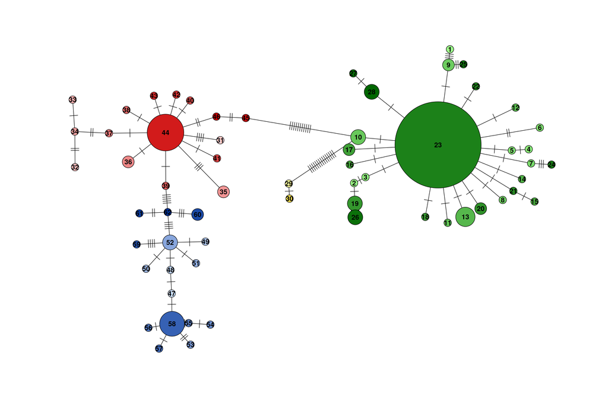

Red de haplotipos de H. americana. Los colores identifican posibles haplogrupos. El tamaño de los cículos representa la frecuencia de los haplotipos. Las líneas perpendiculares en las aristas representan el número de mutaciones presentes entre haplotipos.

```r
# Graficar

coords_manual <- readRDS(
  "hetaerina_lab/03_outputs/coords_red_haplotipos_modificadas.rds"
)

grupo3 <- c(31:46)
grupo4 <- c(47:62)
grupo2 <- c(29, 30)
grupo1 <- setdiff(1:62, c(grupo4, grupo2, grupo3))

# Función personalizada para generar paleta por grupo
asignar_colores <- function(haps, paleta_base) {
  colores <- grDevices::colorRampPalette(paleta_base)(length(haps))
  return(data.frame(hap = haps, color = colores))
}

# Definir paletas base por grupo
colores_df <- bind_rows(
  asignar_colores(grupo1, c("#9cf989", "#006600")), # verdes
  asignar_colores(grupo2, c("#ffff99", "#e8d64e")), # amarillos
  asignar_colores(grupo3, c("#ffcccc", "#cc0000")), # rojos
  asignar_colores(grupo4, c("#cce0ff", "#003399")) # azules
)

mod_freq_hap <- ifelse(freq_hap > 30, freq_hap * 1.5, (log1p(freq_hap)) * 15)


plot(
  red,
  size = mod_freq_hap,
  bg = colores_df$color,
  xy = coords_manual,
  show.mutation = 1,
  main = "Red de haplotipos COI – Libélula",
  threshold = 0
)
```

```r
pdf("hetaerina_lab/03_outputs/red_haplotipos_COI.pdf", width = 15, height = 10)
# Graficar
plot(
  red,
  size = mod_freq_hap, # tamaño de los haplotipos proporcional a su frecuencia
  bg = colores_df$color,
  xy = coords_manual,
  show.mutation = 1, # mostrar número de mutaciones en las ramas
  main = "Red de haplotipos COI – Libélula",
  threshold = 0
)
dev.off()
```

### 3.2.3 Mapa

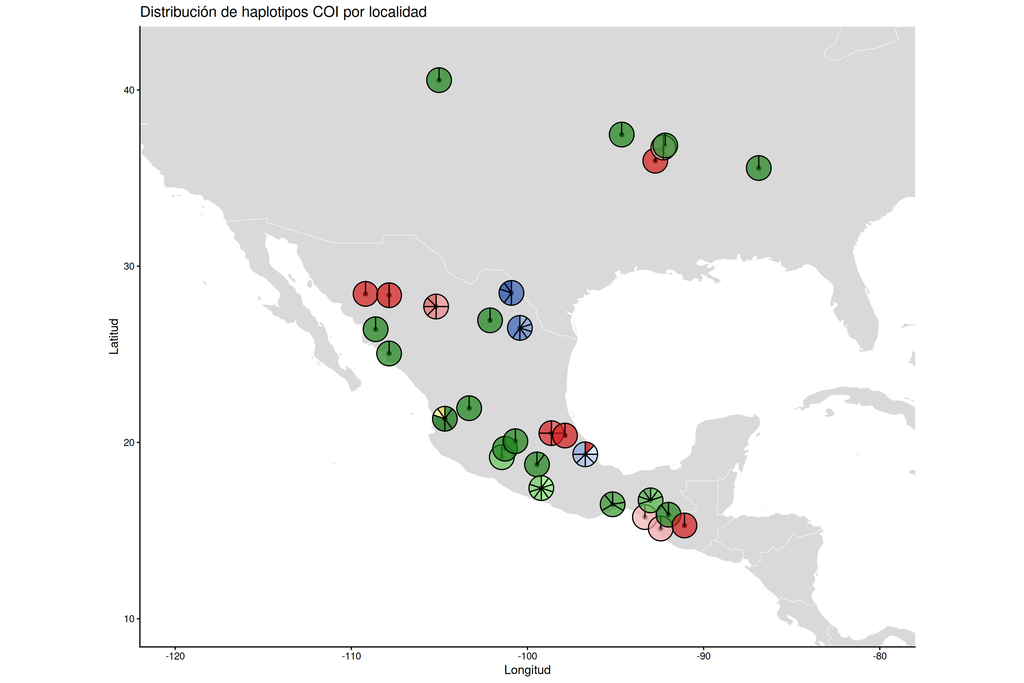

Mapa que representa la distribución geográfica de los haplotipos. Los círculos representan la frecuencia de los haplotipos en cada localidad de colecta. Los colores están asignados de acuerdo a la red de haplotipos.

```r
ind_hap_df <- data.frame(ind = 1:202, hap = ind_hap)
ind_hap_df <- ind_hap_df %>%
  mutate(
    gp = case_when(
      hap %in% grupo1 ~ "gp1",
      hap %in% grupo2 ~ "gp2",
      hap %in% grupo3 ~ "gp3",
      hap %in% grupo4 ~ "gp4"
    )
  ) %>%
  arrange(ind)


metadata_COI <- metadata_COI |> bind_cols(ind_hap_df)

# Calcular proporciones de haplotipos por localidad
pie_data <- metadata_COI %>%
  mutate(hap = paste0("hap", hap)) |>
  group_by(locCode, Lat, Lon, gp, hap) %>%
  summarise(n = n(), .groups = "drop") %>%
  group_by(locCode) %>%
  mutate(n = n / sum(n)) %>% # normalizar a proporciones
  ungroup() %>%
  pivot_wider(
    names_from = hap,
    values_from = n,
    values_fill = 0
  )

hap_cols_ordenados <- gtools::mixedsort(names(pie_data)[4:ncol(pie_data)])

pie_data <- as.data.frame(pie_data)[, c(
  names(pie_data)[1:3],
  hap_cols_ordenados
)]

# Vector de colores con nombres (hap → color)
colores_hap <- setNames(colores_df$color, paste0("hap", colores_df$hap))

# Columnas de haplotipos (todas menos locCode, lat, lon)
hap_cols <- colnames(pie_data)[startsWith(colnames(pie_data), "hap")]

# Generar poligono del mundo
mapa_mundo <- ggplot2::map_data("world")

# Mapa
ggplot() +
  geom_polygon(
    data = mapa_mundo,
    aes(x = long, y = lat, group = group),
    fill = "grey85",
    color = "white",
    linewidth = 0.2
  ) +
  geom_point(data = pie_data, aes(x = Lon, y = Lat)) +
  scatterpie::geom_scatterpie(
    data = pie_data,
    aes(x = Lon, y = Lat, r = 0.7),
    alpha = 0.7,
    cols = colnames(pie_data)[startsWith(colnames(pie_data), "hap")],
    long_format = F
  ) +
  scale_fill_manual(values = colores_hap) +
  coord_fixed(xlim = c(-120, -80), ylim = c(10, 42)) +
  labs(
    title = "Distribución de haplotipos COI por localidad",
    x = "Longitud",
    y = "Latitud",
    fill = "Haplotipo"
  ) +
  theme_classic(base_size = 13) +
  theme(legend.position = "none")
```

**TipTip de reproducibilidad**

Para guardar los paquetes que utilizamos

```r
renv::snapshot()
```

```r
lock <- renv::lockfile_read()

tabla <- data.frame(
  Package = names(lock$Packages),
  Version = sapply(lock$Packages, function(x) x$Version),
  row.names = NULL
)

knitr::kable(tabla)
```

| Package | Version |
| --- | --- |
| BiocGenerics | 0.54.1 |
| BiocManager | 1.30.27 |
| BiocVersion | 3.21.1 |
| Biostrings | 2.76.0 |
| DBI | 1.3.0 |
| GGally | 2.4.0 |
| GenomeInfoDb | 1.44.3 |
| GenomeInfoDbData | 1.2.14 |
| IRanges | 2.42.0 |
| MASS | 7.3-65 |
| Matrix | 1.7-4 |
| PopGenReport | 3.1.3 |
| R.methodsS3 | 1.8.2 |
| R.oo | 1.27.1 |
| R.utils | 2.13.0 |
| R6 | 2.6.1 |
| RColorBrewer | 1.1-3 |
| Rcpp | 1.1.1 |
| RcppArmadillo | 15.2.3-1 |
| RcppEigen | 0.3.4.0.2 |
| RcppParallel | 5.1.11-2 |
| Rdpack | 2.6.6 |
| RgoogleMaps | 1.5.3 |
| S4Vectors | 0.46.0 |
| S7 | 0.2.1 |
| UCSC.utils | 1.4.0 |
| XML | 3.99-0.22 |
| XVector | 0.48.0 |
| ade4 | 1.7-23 |
| adegenet | 2.1.11 |

[output cut: 164 more lines]